# Session Analysis

Jonas Gehrlein @ Web3 Foundation

17/02/2021

```r
# Specify if code should be shown in export
show_code = FALSE
# Specify which network you would like to analyze. Must be "polkadot" or "kusama".
chain = "polkadot"
# Specify which session you would like to analyze. Must be >= 419 for Polkadot and >= 5994 for KSM.
session = 1599
```

# Descriptive metrics

|  | polkadot |
| --- | --- |
| Number of active Nominators: | **6955** |
| Number of active Validators: | **297** |
| Number of oversubscribed Validators: | **4** |
| Number of oversubscribed nominations: | **0** |
| Average commission: | **49.35%** |
| Number of validators with 100% commission: | **134** |
| Number of validators with <100% commission | **163** |
| Average commission for validators with <100% commission: | **7.71%** |
| Average selfstake in DOT | **12460.58** |
| Median selfstake in DOT | **3** |

# Decentralization

Decentralization is an important part of the polkadot network. The following graphs illustrate how votes are distributed across the different validators. One vote corresponds to a specification in the voting scheme. That means, one nominator can have up to 16 votes. This metric is pre-election algorithm, which means that the algorithm was not applied yet and votes have not been redistributed.

Average number of votes per (elected) validator: **274**

## Distribution of voters per validator

The following graphs plots the number of votes (pre-election-algorithm) for each (elected) validator in decreasing order. Note that the set of validators only contain those who are elected and therefore some votes (for not elected) validators are missing. The indicator line is showing a theoretical uniform distribution if all validators receive the same number of votes.

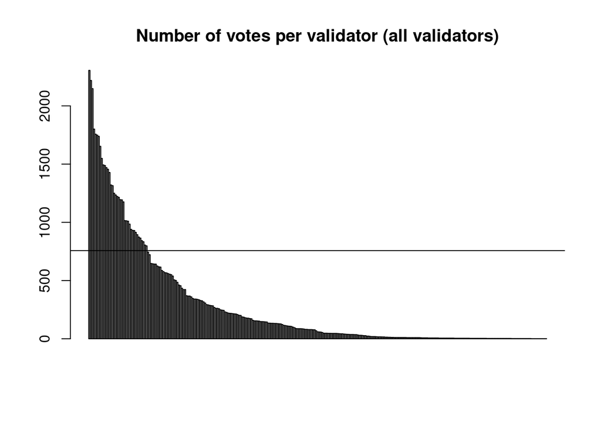

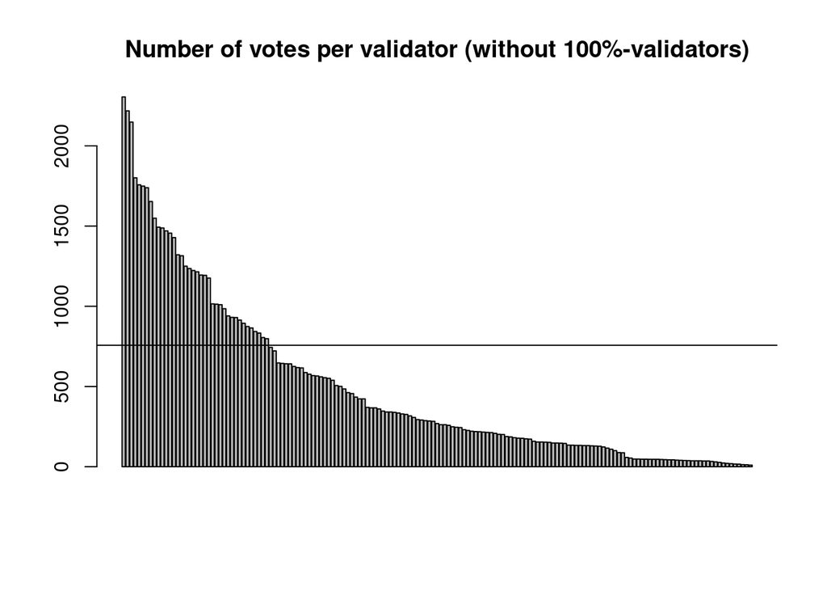

# Security measures

Another major part of the polkadot ecosystem is the security it provides. This depends on the validators who are guarding the system. In order to align incentives between nominators and validators, the latter put down self-stake which is prone to be slashed if they misbehave. That means for a validator to misbehave he/she needs monetary incentives larger than the self-stake lost by attacking plus the potential missing future rewards. **Note:** In this section the **self-stake is adjusted** for validators with 100% commission, because it can be assumed that those are electing themselves. That means, the total_bond is a better approximation of the incentives. For simplicity, future rewards are not incorporated into the analysis and therefore this illustrates the lower bound of security risk.

The average amount of adjusted self-stake per validator (in DOT) is 945072.5 with the median of 10640.95 and the 34%-percentile of 20.07

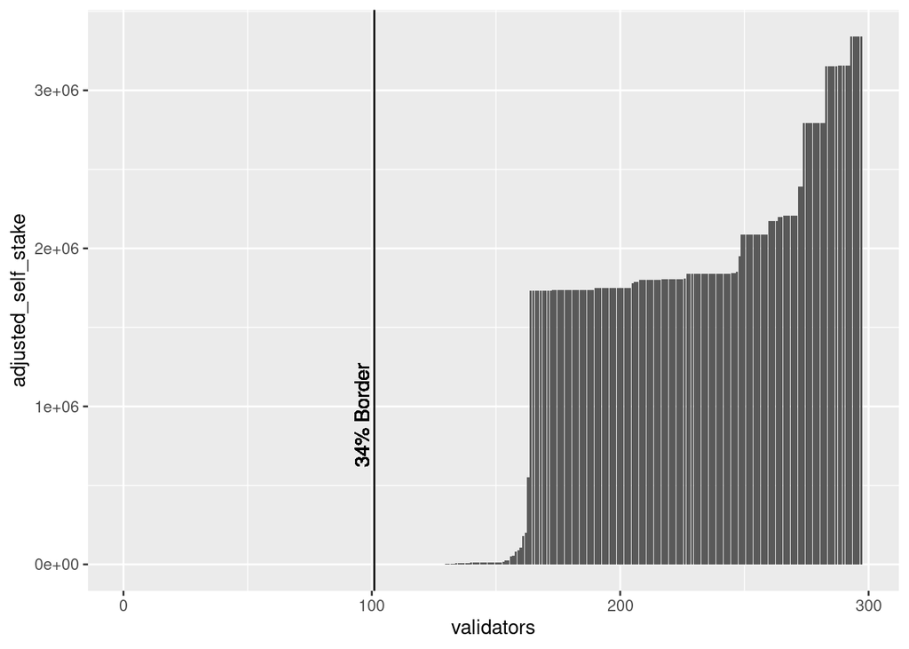

## Bribing of Validators

Bribing the lowest 34% of validators can be considered to be the lower bound for an attack. It neglects the fact that validators who are bribed are losing reputational value and also do not benefit from future rewards.

# Validator total stake

The following graph plots the total stake of the validators and sorts them.

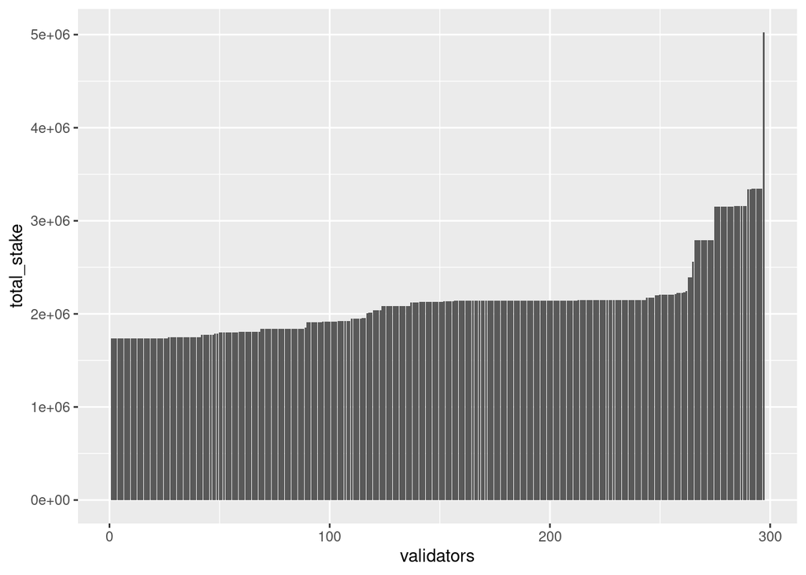

The minimum total stake is 1733870 in comparison to the average total stake of 2124961 which means that the minimum amount is 81.595382% of the average.

# Voting Behavior of Nominators

The following graph shows a histogram of how many targets the nominators select in their voting scheme. It can have values from 1 to 16 (as restricted by the election algorithm). The average number of nominations: **7.92** with a median of **6**

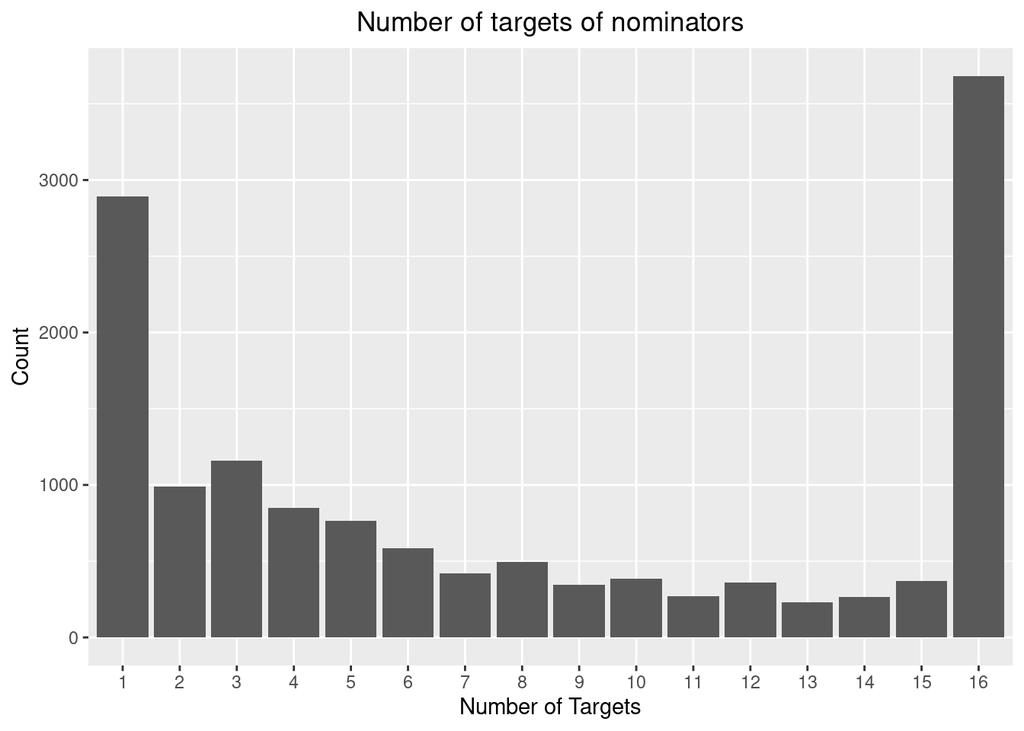

In the following graph, the nominators are grouped by how many targets they select in their voting scheme. It further shows the total amount of bond held by each group (in % with respect to the total available staked bond).

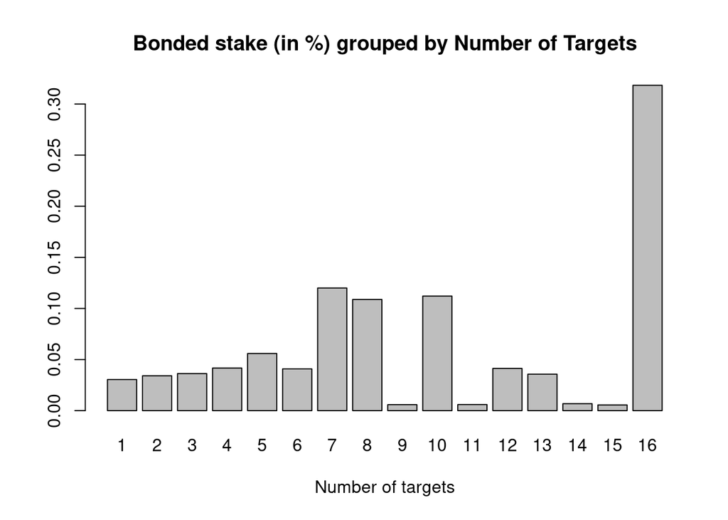

# Allocation of Bonds by Nominators

The following sankeyNetwork illustrates the current staking situation. Nominators are grouped by how much bond they allocate to their nominations. Validators are collapsed to the respective operators (if they have an identity) or to be pseudo-anonymous (if they do not have an identity). A major drawback with plotting the flow of bonds is that the total sum of bond is locked for the whole nomination scheme and the algorithm later decides how to split it. This means that a single bond can be represented 16x in the graph. A naive way to account for that is to only show nominators who have 16 nominations (which is done here).

[interactive chart not shown]

# Distribution of Validator Identity

The following pie-chart illustrates the distribution of validator identities. All validators with an identity but only having one node are summarized as “IWI” (“Individual with Identity”). Pseudo-anonymous nodes are aggregated to the “psydo-a” group. Other operators are aggregated by the first 4 letters of their identity.

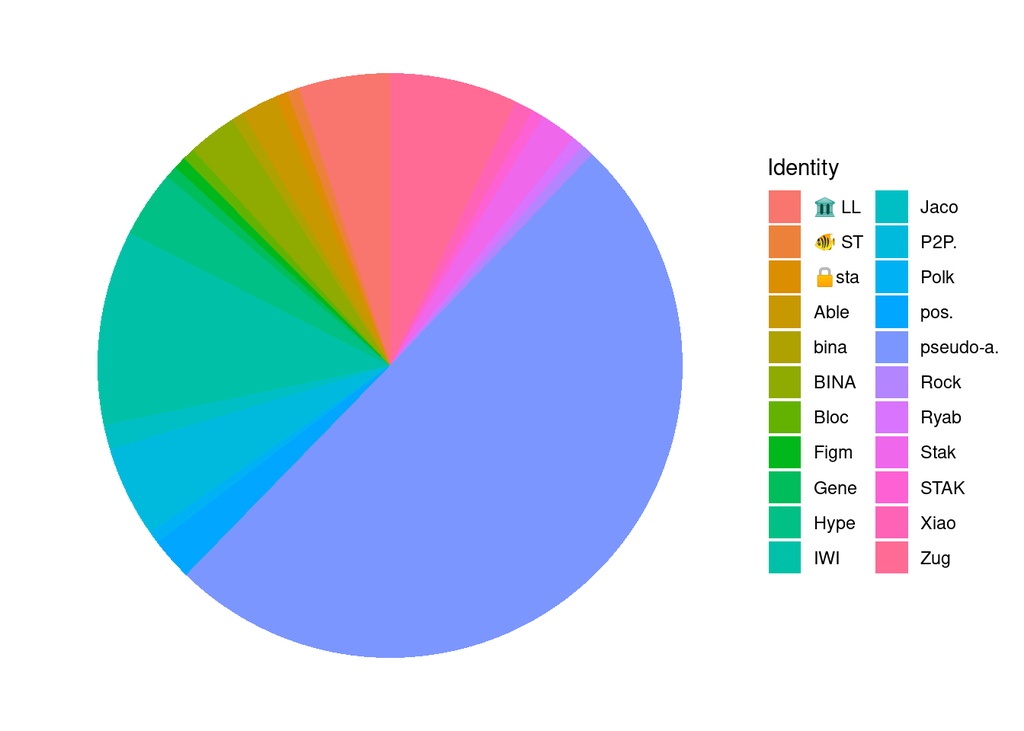

|  | short_identity | number_nodes | self_stake_mean | commission_percent_mean | fraction |
| --- | --- | --- | --- | --- | --- |
| 37 | pseudo-a. | 149 | 14113.5855769 | 73.033557 | 0.502 |
| 53 | Zug | 21 | 10.0000000 | 0.700000 | 0.071 |
| 1 | 🏛 LL | 15 | 0.7333333 | 100.000000 | 0.051 |
| 33 | P2P. | 15 | 1879.9855533 | 3.000000 | 0.051 |
| 23 | Hype | 11 | 1.0000000 | 82.909091 | 0.037 |
| 9 | BINA | 8 | 1.0000000 | 100.000000 | 0.027 |
| 36 | pos. | 7 | 3.0000000 | 2.000000 | 0.024 |
| 6 | Able | 6 | 1.0000000 | 5.000000 | 0.020 |
| 45 | Stak | 6 | 3824.5032840 | 5.333333 | 0.020 |
| 27 | Jaco | 4 | 1.0000000 | 1.000000 | 0.013 |
| 51 | Xiao | 3 | 5490.3825788 | 4.333333 | 0.010 |
| 4 | 🐠 ST | 2 | 41.4163496 | 4.000000 | 0.007 |
| 5 | 🔒sta | 2 | 5334.3864626 | 3.000000 | 0.007 |
| 8 | bina | 2 | 1.0000000 | 100.000000 | 0.007 |
| 10 | Bloc | 2 | 1.4229619 | 5.000000 | 0.007 |
| 20 | Figm | 2 | 53.0764621 | 10.000000 | 0.007 |
| 21 | Gene | 2 | 32923.2892586 | 3.000000 | 0.007 |
| 35 | Polk | 2 | 274765.9357790 | 2.000000 | 0.007 |
| 40 | Rock | 2 | 1707.2159555 | 10.000000 | 0.007 |
| 41 | Ryab | 2 | 5370.7695744 | 2.000000 | 0.007 |
| 46 | STAK | 2 | 5120.8595766 | 5.500000 | 0.007 |
| 2 | 🏢 MI | 1 | 10051.2852227 | 3.000000 | 0.003 |
| 3 | 🐑 HO | 1 | 10085.7995129 | 0.800000 | 0.003 |
| 7 | AG | 1 | 10640.9531086 | 3.000000 | 0.003 |
| 11 | Coin | 1 | 3012.9199781 | 5.000000 | 0.003 |
| 12 | Cont | 1 | 1.0000000 | 10.000000 | 0.003 |
| 13 | COSM | 1 | 10245.1314187 | 3.000000 | 0.003 |
| 14 | CP28 | 1 | 105005.0983173 | 3.000000 | 0.003 |
| 15 | Cryp | 1 | 1.0988137 | 5.000000 | 0.003 |
| 16 | DICO | 1 | 25696.7870061 | 5.000000 | 0.003 |
| 17 | Doki | 1 | 50419.9853000 | 10.000000 | 0.003 |
| 18 | Drag | 1 | 8801.3002334 | 3.000000 | 0.003 |
| 19 | fede | 1 | 1.0000024 | 5.000000 | 0.003 |
| 22 | Gold | 1 | 10000.0000090 | 3.000000 | 0.003 |
| 24 | IBO | 1 | 1129.7331122 | 5.000000 | 0.003 |
| 25 | IOSG | 1 | 5431.8560893 | 5.000000 | 0.003 |
| 26 | IPSE | 1 | 1366.2821913 | 4.000000 | 0.003 |
| 28 | JOIE | 1 | 58.9015984 | 5.000000 | 0.003 |
| 29 | Keep | 1 | 10632.4475931 | 2.000000 | 0.003 |
| 30 | List | 1 | 180486.8966555 | 5.000000 | 0.003 |
| 31 | Mast | 1 | 10358.2322347 | 3.000000 | 0.003 |
| 32 | OMAJ | 1 | 10125.7084034 | 0.000000 | 0.003 |
| 34 | PDP_ | 1 | 10618.5599315 | 2.900000 | 0.003 |
| 38 | QINW | 1 | 1.0000000 | 5.000000 | 0.003 |
| 39 | RAKE | 1 | 10593.5099426 | 0.000000 | 0.003 |
| 42 | SAXE | 1 | 12416.1957455 | 2.000000 | 0.003 |
| 43 | Sio3 | 1 | 10081.9506609 | 3.000000 | 0.003 |
| 44 | SNZP | 1 | 1.0000000 | 1.000000 | 0.003 |
| 47 | Tran | 1 | 88639.4096171 | 4.000000 | 0.003 |
| 48 | Web3 | 1 | 82626.8592789 | 5.000000 | 0.003 |
| 49 | Wei | 1 | 200400.5388214 | 1.000000 | 0.003 |
| 50 | Wei | 1 | 407.9049371 | 1.000000 | 0.003 |
| 52 | ZKVa | 1 | 1.0000000 | 8.000000 | 0.003 |

# Determinants of Voting Behavior

The following linear regression predicts the number of stakers per validator by whether the validator has an identity, the percentage of commission and the amount of self-stake. Validators with $100$% commission are excluded as they probably are self-electing and do not contribute to a meaningful analysis.

```
##
## Call:
## glm(formula = voters ~ commission_percent + identity + self_stake,
##     family = gaussian(link = "identity"), data = validators_regression)
##
## Deviance Residuals:
##     Min       1Q   Median       3Q      Max
## -626.30  -296.79   -53.83   130.40  1483.26
##
## Coefficients:
##                      Estimate Std. Error t value Pr(>|t|)
## (Intercept)         4.096e+02  1.190e+02   3.441 0.000741 ***
## commission_percent -1.883e+01  5.801e+00  -3.246 0.001429 **
## identity            2.683e+02  1.096e+02   2.449 0.015429 *
## self_stake          3.173e-03  6.433e-04   4.932 2.03e-06 ***
## ---
## Signif. codes:  0 '***' 0.001 '**' 0.01 '*' 0.05 '.' 0.1 ' ' 1
##
## (Dispersion parameter for gaussian family taken to be 160153.4)
##
##     Null deviance: 43098949  on 162  degrees of freedom
## Residual deviance: 25464390  on 159  degrees of freedom
## AIC: 2421.9
##
## Number of Fisher Scoring iterations: 2
```

# Gini Index

The following analysis calculates the gini index of the bonded amount by the nominators. It also plots the corresponding lorenz curve. Note, that this takes only data of nominators and their bond. It does not include all accounts for the network and cannot make a statement about whether user have multiple nominators.

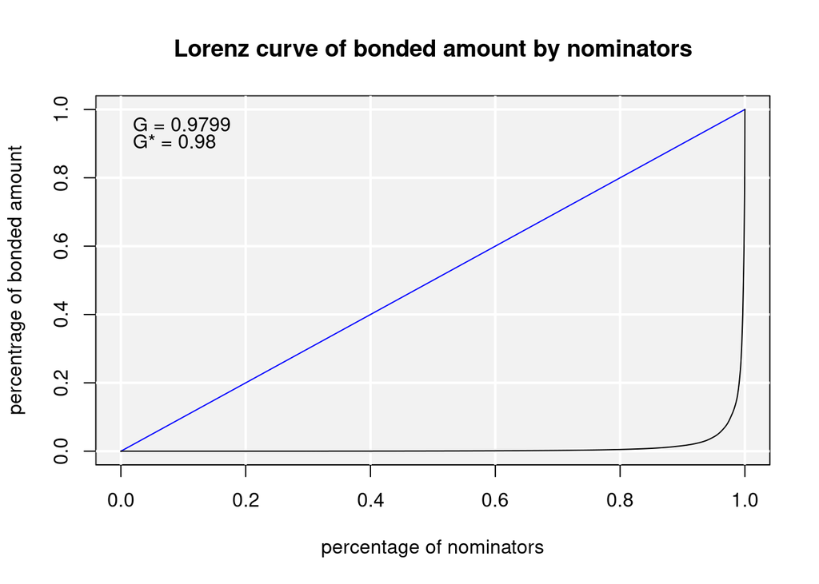

```
## [1] 0.9799453
```

```
## [1] 0.980015
```